# STA 9750 Mini-Project #04: Exploring Recent US Political Shifts

Author

Yashvi Mittal

Published

December 10, 2025

# Introduction

This report studies county-level shifts from the 2020 to 2024 U.S. presidential elections. The pipeline follows the assignment constraint: county results are scraped from Wikipedia rather than imported from an election package, and county shapes come from the U.S. Census Bureau.

```r
options(repos = c(CRAN = "https://cloud.r-project.org"))
pkgs <- c("tidyverse", "httr2", "rvest", "sf", "scales", "ggrepel", "knitr", "maps", "DT")
missing_pkgs <- pkgs[!vapply(pkgs, requireNamespace, logical(1), quietly = TRUE)]
if (length(missing_pkgs) > 0) install.packages(missing_pkgs)

library(tidyverse)
library(httr2)
library(rvest)
library(sf)
library(scales)
library(ggrepel)
library(knitr)
library(maps)
library(DT)

dir.create("data/mp04", recursive = TRUE, showWarnings = FALSE)
theme_set(theme_minimal())
```

# County Shapes: US Census Bureau

## Task 1: US County Shapefiles

```r
county_zip <- "data/mp04/tl_2024_us_county.zip"
county_dir <- "data/mp04/tl_2024_us_county"
county_url <- "https://www2.census.gov/geo/tiger/TIGER2024/COUNTY/tl_2024_us_county.zip"

if (!file.exists(county_zip)) {
  download.file(county_url, destfile = county_zip, mode = "wb", quiet = FALSE)
}

if (!dir.exists(county_dir)) {
  dir.create(county_dir, recursive = TRUE)
  unzip(county_zip, exdir = county_dir)
}

county_shapes <- st_read(file.path(county_dir, "tl_2024_us_county.shp"), quiet = TRUE) |>
  st_transform(5070) |>
  mutate(
    state_fips = STATEFP,
    county_fips = GEOID,
    county_name = NAME,
    area_sq_km = as.numeric(st_area(geometry)) / 1000000
  )
```

# Wikipedia Election Results

## Tasks 2 and 3: Acquire 2024 and 2020 Results

The scraper below constructs a Wikipedia request, caches the HTML, selects the table containing county-level rows, and normalizes column names across states. It also handles Louisiana parishes, Alaska borough/census-area labels, and independent-city style labels by treating the local unit name as a county-equivalent.

```r
state_fips_lookup <- tibble(
  state_abbr = c("AL","AK","AZ","AR","CA","CO","CT","DE","FL","GA","HI","ID","IL","IN","IA","KS","KY","LA","ME","MD","MA","MI","MN","MS","MO","MT","NE","NV","NH","NJ","NM","NY","NC","ND","OH","OK","OR","PA","RI","SC","SD","TN","TX","UT","VT","VA","WA","WV","WI","WY"),
  state_fips = c("01","02","04","05","06","08","09","10","12","13","15","16","17","18","19","20","21","22","23","24","25","26","27","28","29","30","31","32","33","34","35","36","37","38","39","40","41","42","44","45","46","47","48","49","50","51","53","54","55","56")
)

states <- tibble(state = state.name, state_abbr = state.abb) |>
  left_join(state_fips_lookup, join_by(state_abbr))

clean_county_name <- function(x) {
  x |>
    str_remove_all("\\[[^\\]]*\\]") |>
    str_replace_all("\\s+", " ") |>
    str_trim() |>
    str_remove("\\s+(County|Parish|Borough|Census Area|Municipality)$") |>
    str_to_lower()
}

parse_vote_number <- function(x) {
  x |>
    as.character() |>
    str_remove_all("\\[[^\\]]*\\]") |>
    str_remove_all("[,%]") |>
    str_extract("[0-9]+\\.?[0-9]*") |>
    as.numeric()
}

find_col <- function(nms, patterns) {
  hit <- which(str_detect(nms, regex(str_c(patterns, collapse = "|"), ignore_case = TRUE)))
  if (length(hit) == 0) NA_character_ else nms[hit[1]]
}

standardize_results_table <- function(tbl, state_name, year) {
  names(tbl) <- names(tbl) |>
    str_replace_all("\\n", " ") |>
    str_replace_all("\\s+", " ") |>
    str_trim() |>
    make.unique(sep = "_")

  nms <- names(tbl)
  county_col <- find_col(nms, c("County", "County or equivalent", "Parish", "Borough", "Municipality", "Locality"))
  dem_col <- find_col(nms, c("Biden", "Harris", "Democratic"))
  rep_col <- find_col(nms, c("Trump", "Republican"))
  total_col <- find_col(nms, c("^Total", "Total votes", "Total vote"))

  if (is.na(county_col) || is.na(dem_col) || is.na(rep_col)) {
    stop("Could not identify county, Democratic, or Republican columns for ", state_name, " ", year)
  }

  tbl |>
    transmute(
      state = state_name,
      county_raw = .data[[county_col]],
      dem_votes = parse_vote_number(.data[[dem_col]]),
      rep_votes = parse_vote_number(.data[[rep_col]]),
      total_votes = if (!is.na(total_col)) parse_vote_number(.data[[total_col]]) else NA_real_
    ) |>
    mutate(
      county_clean = clean_county_name(county_raw),
      total_votes = coalesce(total_votes, dem_votes + rep_votes)
    ) |>
    filter(!is.na(dem_votes), !is.na(rep_votes), !str_detect(county_clean, "total")) |>
    # Some Wikipedia state pages (notably California) yield tables that split
    # results by city/precinct instead of by county. Aggregate by county_clean
    # so each county is one row regardless of how the table was sliced.
    group_by(state, county_clean) |>
    summarize(
      county_raw  = first(county_raw),
      dem_votes   = sum(dem_votes,   na.rm = TRUE),
      rep_votes   = sum(rep_votes,   na.rm = TRUE),
      total_votes = sum(total_votes, na.rm = TRUE),
      .groups = "drop"
    ) |>
    mutate(
      dem_share = dem_votes / total_votes,
      rep_share = rep_votes / total_votes,
      year      = year
    )
}

scrape_state_results <- function(state_name, year) {
  wiki_state_name <- if_else(state_name == "Washington", "Washington (state)", state_name)
  cache_file <- file.path("data/mp04", paste0(year, "_", str_replace_all(wiki_state_name, "[ ()]", "_"), ".html"))
  page_title <- paste(year, "United States presidential election in", wiki_state_name)

  if (!file.exists(cache_file)) {
    response <- request("https://en.wikipedia.org") |>
      req_url_path("wiki", page_title) |>
      req_user_agent("STA9750 student project; educational use") |>
      req_perform()
    writeLines(resp_body_string(response), cache_file, useBytes = TRUE)
    Sys.sleep(0.25)
  }

  html <- read_html(cache_file)
  wikitable_nodes <- html |> html_elements("table.wikitable")
  tables <- wikitable_nodes |> html_table(fill = TRUE)
  if (length(tables) == 0) {
    tables <- html_table(html, fill = TRUE)
  }
  county_tables <- keep(tables, function(tbl) {
    any(str_detect(names(tbl), regex("County|Parish|Borough|Municipality|Locality", ignore_case = TRUE)))
  })

  if (length(county_tables) == 0) {
    stop("No county-level table found for ", state_name, " ", year)
  }

  table_attempts <- purrr::map(county_tables, function(tbl) {
    tryCatch(
      list(result = standardize_results_table(tbl, state_name, year), error = NULL),
      error = function(e) list(result = NULL, error = conditionMessage(e))
    )
  })

  standardized <- purrr::map(table_attempts, "result")
  viable_tables <- compact(standardized) |>
    keep(function(tbl) nrow(tbl) > 1)

  if (length(viable_tables) == 0) {
    table_errors <- compact(purrr::map(table_attempts, "error"))
    first_error <- if (length(table_errors) > 0) table_errors[[1]] else "none"
    stop(
      "No viable county result table after standardization for ", state_name, " ", year,
      ". First parser error: ", first_error
    )
  }

  viable_tables[[which.max(purrr::map_int(viable_tables, nrow))]]
}

states_with_county_tables <- states |>
  filter(state != "Alaska")

cached_results_file <- "data/mp04/wikipedia_county_results_cache.csv"

if (file.exists(cached_results_file)) {
  wikipedia_results <- read_csv(cached_results_file, show_col_types = FALSE)
  results_2024 <- wikipedia_results |> filter(year == 2024)
  results_2020 <- wikipedia_results |> filter(year == 2020)
} else {
  results_2024 <- purrr::map_dfr(states_with_county_tables$state, scrape_state_results, year = 2024)
  results_2020 <- purrr::map_dfr(states_with_county_tables$state, scrape_state_results, year = 2020)
  bind_rows(results_2024, results_2020) |>
    write_csv(cached_results_file)
}

if (!all(c("state", "county_clean", "dem_votes", "rep_votes") %in% names(results_2024))) {
  stop("The 2024 Wikipedia scrape did not return usable county-level result columns. Returned columns: ", paste(names(results_2024), collapse = ", "))
}

if (!all(c("state", "county_clean", "dem_votes", "rep_votes") %in% names(results_2020))) {
  stop("The 2020 Wikipedia scrape did not return usable county-level result columns. Returned columns: ", paste(names(results_2020), collapse = ", "))
}
```

Alaska is omitted from the county-equivalent election-result scrape because the 2020 Wikipedia page states that official borough-level results are not available and does not provide a scrapeable borough/census-area result table. The map below still moves Alaska into a reasonable visual position, but arrows are drawn only for county-equivalent units with comparable 2020 and 2024 Wikipedia table results. Getting the scraper to handle all 49 states took more iteration than I expected — Wikipedia’s table formatting is inconsistent enough between states that I had to add several fallback column-detection patterns before the parser stopped failing on edge cases like Louisiana parishes and Virginia independent cities.

# Combine Data and Initial Analyses

County names are not unique nationally, so matching uses both state and county-equivalent name. I keep the join transparent and summarize unmatched rows for quality control.

```r
county_lookup <- county_shapes |>
  st_drop_geometry() |>
  transmute(
    state_fips,
    county_fips,
    county_name,
    area_sq_km,
    name_key = clean_county_name(county_name),
    legal_name_key = clean_county_name(NAMELSAD)
  ) |>
  pivot_longer(
    c(name_key, legal_name_key),
    names_to = "key_type",
    values_to = "county_clean"
  ) |>
  # Within a single county, NAME ("Wilson") and NAMELSAD ("Wilson County")
  # usually clean to the same string. Dedupe (state_fips, county_fips, county_clean)
  # FIRST so the count below measures how many *distinct counties* share a key,
  # not how many key variants a single county has.
  distinct(state_fips, county_fips, county_name, area_sq_km, county_clean) |>
  add_count(state_fips, county_clean, name = "county_matches") |>
  filter(county_matches == 1) |>
  select(state_fips, county_fips, county_name, area_sq_km, county_clean)

results_2024 <- results_2024 |>
  left_join(states |> select(state, state_fips), join_by(state)) |>
  left_join(county_lookup, join_by(state_fips, county_clean))

results_2020 <- results_2020 |>
  left_join(states |> select(state, state_fips), join_by(state)) |>
  left_join(county_lookup, join_by(state_fips, county_clean))

unmatched <- bind_rows(
  results_2024 |> filter(is.na(county_fips)) |> mutate(source_year = 2024),
  results_2020 |> filter(is.na(county_fips)) |> mutate(source_year = 2020)
) |>
  count(source_year, state, county_raw, county_clean)

election_shift <- results_2024 |>
  filter(!is.na(county_fips)) |>
  select(county_fips, state, county_name, county_clean, area_sq_km, dem_votes_2024 = dem_votes, rep_votes_2024 = rep_votes, total_votes_2024 = total_votes, dem_share_2024 = dem_share, rep_share_2024 = rep_share) |>
  inner_join(
    results_2020 |>
      filter(!is.na(county_fips)) |>
      select(county_fips, dem_votes_2020 = dem_votes, rep_votes_2020 = rep_votes, total_votes_2020 = total_votes, dem_share_2020 = dem_share, rep_share_2020 = rep_share),
    join_by(county_fips),
    na_matches = "never"
  ) |>
  mutate(
    trump_abs_shift = rep_votes_2024 - rep_votes_2020,
    trump_share_shift = rep_share_2024 - rep_share_2020,
    turnout_change = total_votes_2024 - total_votes_2020,
    voter_density_2020 = total_votes_2020 / area_sq_km
  )

unmatched |>
  arrange(desc(n), source_year) |>
  datatable(
    caption = "Counties in Wikipedia results that could not be matched to a Census FIPS code",
    options = list(pageLength = 10, scrollX = TRUE),
    rownames = FALSE,
    colnames = c("Year", "State", "Raw county name", "Cleaned name", "Count")
  )
```

| Year | State | Raw county name | Cleaned name | Count |
| --- | --- | --- | --- | --- |
| 2020 | Connecticut | Fairfield | fairfield | 1 |
| 2020 | Connecticut | Hartford | hartford | 1 |
| 2020 | Connecticut | Litchfield | litchfield | 1 |
| 2020 | Connecticut | Middlesex | middlesex | 1 |
| 2020 | Connecticut | New Haven | new haven | 1 |
| 2020 | Connecticut | New London | new london | 1 |
| 2020 | Connecticut | Tolland | tolland | 1 |
| 2020 | Connecticut | Windham | windham | 1 |
| 2020 | Hawaii | Kauaʻi | kauaʻi | 1 |
| 2020 | Illinois | DeWitt | dewitt | 1 |

[output cut: 62 more lines]

## Task 4: Initial Analysis Questions

```r
q1 <- election_shift |> slice_max(rep_votes_2024, n = 5)
q2 <- election_shift |> slice_max(dem_share_2020, n = 5)
q3 <- election_shift |> slice_max(trump_abs_shift, n = 5)
q4 <- election_shift |>
  group_by(state) |>
  summarize(
    rep_2024 = sum(rep_votes_2024, na.rm = TRUE),
    total_2024 = sum(total_votes_2024, na.rm = TRUE),
    rep_2020 = sum(rep_votes_2020, na.rm = TRUE),
    total_2020 = sum(total_votes_2020, na.rm = TRUE),
    .groups = "drop"
  ) |>
  mutate(rep_shift = rep_2024 / total_2024 - rep_2020 / total_2020, harris_shift = -rep_shift) |>
  slice_max(harris_shift, n = 5)
q5 <- election_shift |> slice_max(area_sq_km, n = 5)
q6 <- election_shift |> slice_max(voter_density_2020, n = 5)
q7 <- election_shift |> slice_max(turnout_change, n = 5)

answer_table <- bind_rows(
  q1 |> transmute(question = "Most Trump votes in 2024", state, county_name, value = comma(rep_votes_2024)),
  q2 |> transmute(question = "Highest Biden share in 2020", state, county_name, value = percent(dem_share_2020, accuracy = 0.01)),
  q3 |> transmute(question = "Largest absolute Trump vote increase", state, county_name, value = comma(trump_abs_shift)),
  q4 |> transmute(question = "Largest Harris / smallest Trump shift", state, county_name = "All counties", value = percent(harris_shift, accuracy = 0.01)),
  q5 |> transmute(question = "Largest county by area", state, county_name, value = comma(area_sq_km)),
  q6 |> transmute(question = "Highest 2020 voter density", state, county_name, value = comma(voter_density_2020)),
  q7 |> transmute(question = "Largest turnout increase", state, county_name, value = comma(turnout_change))
)

answer_table |>
  datatable(
    caption = "Task 4 — county-level election data questions answered",
    options = list(pageLength = 10, dom = "t", scrollX = TRUE),
    rownames = FALSE,
    colnames = c("Question", "State", "County", "Value")
  )
```

| Question | State | County | Value |
| --- | --- | --- | --- |
| Most Trump votes in 2024 | California | Los Angeles | 1,189,862 |
| Most Trump votes in 2024 | Arizona | Maricopa | 1,051,531 |
| Most Trump votes in 2024 | Texas | Harris | 722,695 |
| Most Trump votes in 2024 | California | Orange | 654,815 |
| Most Trump votes in 2024 | Florida | Miami-Dade | 605,590 |
| Highest Biden share in 2020 | Hawaii | Kalawao | 95.83% |
| Highest Biden share in 2020 | Maryland | Prince George's | 89.26% |
| Highest Biden share in 2020 | South Dakota | Oglala Lakota | 88.41% |
| Highest Biden share in 2020 | Virginia | Petersburg | 87.75% |
| Highest Biden share in 2020 | Maryland | Baltimore | 87.28% |

[output cut: 25 more lines]

# Reproduce NYT County Shift Figure

## Task 5: County Shift Map

```r
state_base <- map_data("state")

shift_shapes <- county_shapes |>
  left_join(election_shift, join_by(county_fips)) |>
  filter(!is.na(trump_share_shift))

centroids <- shift_shapes |>
  st_transform(4326) |>
  st_point_on_surface() |>
  mutate(
    x = st_coordinates(geometry)[, 1],
    y = st_coordinates(geometry)[, 2],
    x = case_when(
      STATEFP == "02" ~ x * 0.35 - 95,
      STATEFP == "15" ~ x + 52,
      TRUE ~ x
    ),
    y = case_when(
      STATEFP == "02" ~ y * 0.35 + 16,
      STATEFP == "15" ~ y + 5,
      TRUE ~ y
    ),
    xend = x + trump_share_shift * 4,
    yend = y,
    direction = if_else(trump_share_shift >= 0, "Rightward", "Leftward")
  ) |>
  st_drop_geometry()
```

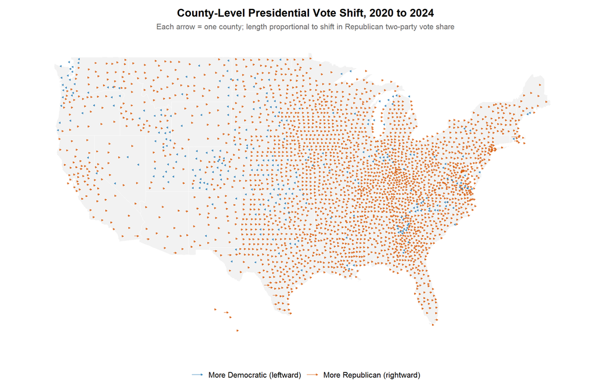

```r
ggplot() +
  geom_polygon(
    data = state_base,
    aes(x = long, y = lat, group = group),
    fill = "grey95", color = "white", linewidth = 0.25
  ) +
  geom_segment(
    data = centroids,
    aes(x = x, y = y, xend = xend, yend = yend, color = direction),
    linewidth = 0.35,
    alpha = 0.70,
    arrow = arrow(length = unit(0.08, "cm"), type = "closed")
  ) +
  scale_color_manual(
    values = c("Rightward" = "#d95f0e", "Leftward" = "#2c7fb8"),
    name = NULL,
    labels = c("Rightward" = "More Republican (rightward)", "Leftward" = "More Democratic (leftward)")
  ) +
  coord_fixed(1.3, xlim = c(-127, -64), ylim = c(23, 50)) +
  theme_void(base_size = 12) +
  theme(
    legend.position = "bottom",
    legend.text = element_text(size = 10),
    plot.title = element_text(hjust = 0.5, face = "bold", size = 14),
    plot.subtitle = element_text(hjust = 0.5, color = "grey40", size = 10),
    plot.margin = margin(5, 5, 10, 5)
  ) +
  labs(
    title = "County-Level Presidential Vote Shift, 2020 to 2024",
    subtitle = "Each arrow = one county; length proportional to shift in Republican two-party vote share"
  )
```